# Practical Machine Learning Course Project

Philip Glaeser

December 9, 2017

## Introduction

Human Activity Recognition aims to recognize the actions of a person from a series of observations about the person’s actions. Common examples include the use of devices like Jawbone Up, Nike FuelBand, and Fitbit to collect data about personal activity. People regularly quantify how much of a particular activity they do, but rarely quantify how well they do it. 6 participantes were asked to perform barbell lifts in the correct manner and incorrectly in four other manners that are common flaws in techique.

The goal of this project is to use data from accelerometers on the belt, forearm, arm, and dumbell to build a model which can predict the manner in which they did the exercise. Each manner is represented by a different letter in the “classe” variable in the training set.

More information is available from the website here: http://groupware.les.inf.puc-rio.br/har (see the section on the Weight Lifting Exercise Dataset).

## Data

The data for this project come from this source: http://groupware.les.inf.puc-rio.br/har and the author thanks the owners for the use of their data.

The training data are available here:

https://d396qusza40orc.cloudfront.net/predmachlearn/pml-training.csv

The test (validation) data are available here:

https://d396qusza40orc.cloudfront.net/predmachlearn/pml-testing.csv

The test data is really used as the final validation data. For the purposes of building the model, the training data will be divided into training and test sets.

### Required Packages

The R environment is set up with the required packages and a seed is set to ensure reproducibility of the results.

```r
library(caret)
library(rpart)
library(rattle)
library(randomForest)
set.seed(827)
```

### Data Preparation

#### Loading

The data from the above mention sources is downloaded to a local directory prior to loading into the R environment.

```r
trainI <- read.csv("pml-training.csv")
testF <- read.csv("pml-testing.csv")
```

#### Cleaning

The there are many columns where the data is either blank or “NA” Blanks are replaced with “NA” and then all columns where more than 50% of the entires are “NA” are eliminated.

Variables not related to exercise measurements are removed.

#### Cross-validation

The supplied training date is split into a model training set (70% of data) and a model testing set (30% of data). The test data set supplied is really used as the final validation data.

```r
inTrain <- createDataPartition(y=trainI$classe, p=0.7, list=FALSE)
trainD <- trainI[inTrain, ]
testD <- trainI[-inTrain, ]
dim(trainD)
```

```
## [1] 13737    53
```

```r
dim(testD)
```

```
## [1] 5885   53
```

## Decision Tree Prediction Model

This model is tried first as it is simple and quick in execution. Unfortunately, as can be seen in the output of the confusion matrix, the accuracy is only 75.85%. We will look at another model in hopes to find a better result. Further details on the Decision Tree Model are contained in the appendix.

```r
modFit <- rpart(classe ~ ., data=trainD, method="class")
## print(modFit)
## fancyRpartPlot(modFit)
predictions <- predict(modFit, testD, type = "class")
```

```r
confusionMatrix(predictions, testD$classe)
```

```
## Confusion Matrix and Statistics
##
##           Reference
## Prediction    A    B    C    D    E
##          A 1519  163   23   51   22
##          B   61  722  102   84  100
##          C   47  121  827  154  120
##          D   17   83   54  617   61
##          E   30   50   20   58  779
##
## Overall Statistics
##
##                Accuracy : 0.7585
##                  95% CI : (0.7474, 0.7694)
##     No Information Rate : 0.2845
##     P-Value [Acc > NIR] : < 2.2e-16
##
##                   Kappa : 0.6939
##  Mcnemar's Test P-Value : < 2.2e-16
##
## Statistics by Class:
##
##                      Class: A Class: B Class: C Class: D Class: E
## Sensitivity            0.9074   0.6339   0.8060   0.6400   0.7200
## Specificity            0.9385   0.9269   0.9090   0.9563   0.9671
## Pos Pred Value         0.8543   0.6754   0.6517   0.7416   0.8314
## Neg Pred Value         0.9623   0.9134   0.9569   0.9313   0.9388
## Prevalence             0.2845   0.1935   0.1743   0.1638   0.1839
## Detection Rate         0.2581   0.1227   0.1405   0.1048   0.1324
## Detection Prevalence   0.3021   0.1816   0.2156   0.1414   0.1592
## Balanced Accuracy      0.9230   0.7804   0.8575   0.7982   0.8435
```

## Random Forest Predition Model

### Random Forest Predition Model Training

```r
modFitRF <- randomForest(classe ~. , data=trainD)
print(modFitRF)
```

```
##
## Call:
##  randomForest(formula = classe ~ ., data = trainD)
##                Type of random forest: classification
##                      Number of trees: 500
## No. of variables tried at each split: 7
##
##         OOB estimate of  error rate: 0.54%
## Confusion matrix:
##      A    B    C    D    E class.error
## A 3902    3    1    0    0 0.001024066
## B   11 2642    5    0    0 0.006019564
## C    0   16 2379    1    0 0.007095159
## D    0    0   26 2224    2 0.012433393
## E    0    0    1    8 2516 0.003564356
```

### Random Forest Predition Model Testing

As seen in the output below, the Random Forest Model produces an accuracy of 99.32%, far superior to the Decision Tree Model.

```r
predictionsRF <- predict(modFitRF, testD, type = "class")
confusionMatrix(predictionsRF, testD$classe)
```

```
## Confusion Matrix and Statistics
##
##           Reference
## Prediction    A    B    C    D    E
##          A 1673    5    0    0    0
##          B    1 1127   11    0    0
##          C    0    7 1015   10    0
##          D    0    0    0  954    6
##          E    0    0    0    0 1076
##
## Overall Statistics
##
##                Accuracy : 0.9932
##                  95% CI : (0.9908, 0.9951)
##     No Information Rate : 0.2845
##     P-Value [Acc > NIR] : < 2.2e-16
##
##                   Kappa : 0.9914
##  Mcnemar's Test P-Value : NA
##
## Statistics by Class:
##
##                      Class: A Class: B Class: C Class: D Class: E
## Sensitivity            0.9994   0.9895   0.9893   0.9896   0.9945
## Specificity            0.9988   0.9975   0.9965   0.9988   1.0000
## Pos Pred Value         0.9970   0.9895   0.9835   0.9937   1.0000
## Neg Pred Value         0.9998   0.9975   0.9977   0.9980   0.9988
## Prevalence             0.2845   0.1935   0.1743   0.1638   0.1839
## Detection Rate         0.2843   0.1915   0.1725   0.1621   0.1828
## Detection Prevalence   0.2851   0.1935   0.1754   0.1631   0.1828
## Balanced Accuracy      0.9991   0.9935   0.9929   0.9942   0.9972
```

```r
predict(modFitRF,testF)
```

```
##  1  2  3  4  5  6  7  8  9 10 11 12 13 14 15 16 17 18 19 20
##  B  A  B  A  A  E  D  B  A  A  B  C  B  A  E  E  A  B  B  B
## Levels: A B C D E
```

## Appendix

### Further result from the Desition Tree Prediction Model

Results of the attenpt at the tree model are shown below, both the raw data and a visual tree output.

```
## n= 13737
##
## node), split, n, loss, yval, (yprob)
##       * denotes terminal node
##
##     1) root 13737 9831 A (0.28 0.19 0.17 0.16 0.18)
##       2) roll_belt< 130.5 12596 8698 A (0.31 0.21 0.19 0.18 0.11)
##         4) pitch_forearm< -34.35 1120    4 A (1 0.0036 0 0 0) *
##         5) pitch_forearm>=-34.35 11476 8694 A (0.24 0.23 0.21 0.2 0.12)
##          10) magnet_dumbbell_y< 439.5 9713 6986 A (0.28 0.18 0.24 0.19 0.11)
##            20) roll_forearm< 123.5 6073 3620 A (0.4 0.19 0.18 0.17 0.061)
##              40) magnet_dumbbell_z< -24.5 2146  730 A (0.66 0.21 0.02 0.081 0.032)
##                80) roll_forearm>=-136.5 1796  414 A (0.77 0.17 0.022 0.031 0.0067) *
##                81) roll_forearm< -136.5 350  212 B (0.097 0.39 0.0086 0.34 0.16) *
##              41) magnet_dumbbell_z>=-24.5 3927 2858 C (0.26 0.17 0.27 0.21 0.077)
##                82) yaw_belt>=169.5 461   60 A (0.87 0.059 0 0.072 0) *
##                83) yaw_belt< 169.5 3466 2397 C (0.18 0.19 0.31 0.23 0.087)
##                 166) pitch_belt< -42.95 391   70 B (0.018 0.82 0.1 0.041 0.02) *
##                 167) pitch_belt>=-42.95 3075 2045 C (0.2 0.11 0.33 0.26 0.096)
##                   334) accel_dumbbell_y>=-40.5 2616 1841 D (0.24 0.12 0.24 0.3 0.11)
##                     668) roll_belt>=125.5 622  250 C (0.36 0.024 0.6 0.008 0.0048)
##                      1336) magnet_belt_z< -323.5 199    6 A (0.97 0 0.015 0 0.015) *
##                      1337) magnet_belt_z>=-323.5 423   54 C (0.08 0.035 0.87 0.012 0) *
##                     669) roll_belt< 125.5 1994 1224 D (0.2 0.15 0.13 0.39 0.14)
##                      1338) pitch_belt>=1.04 1266  978 D (0.23 0.21 0.14 0.23 0.19)
##                        2676) accel_dumbbell_z< 24.5 765  497 A (0.35 0.13 0.23 0.27 0.029)
##                          5352) yaw_forearm>=-94.65 558  290 A (0.48 0.17 0.24 0.081 0.029)
##                           10704) magnet_forearm_z>=-129 360   97 A (0.73 0.13 0.017 0.097 0.028) *
##                           10705) magnet_forearm_z< -129 198   70 C (0.025 0.25 0.65 0.051 0.03) *
##                          5353) yaw_forearm< -94.65 207   49 D (0 0.019 0.19 0.76 0.029) *
##                        2677) accel_dumbbell_z>=24.5 501  280 E (0.038 0.34 0.01 0.17 0.44)
##                          5354) roll_dumbbell< 38.61985 169   39 B (0.041 0.77 0.03 0.047 0.11) *
##                          5355) roll_dumbbell>=38.61985 332  130 E (0.036 0.12 0 0.23 0.61) *
##                      1339) pitch_belt< 1.04 728  246 D (0.15 0.034 0.11 0.66 0.043)
##                        2678) yaw_arm< -101 102    0 A (1 0 0 0 0) *
##                        2679) yaw_arm>=-101 626  144 D (0.016 0.04 0.12 0.77 0.05) *
##                   335) accel_dumbbell_y< -40.5 459   57 C (0.0065 0.05 0.88 0.028 0.039) *
##            21) roll_forearm>=123.5 3640 2432 C (0.075 0.17 0.33 0.23 0.19)
##              42) magnet_dumbbell_y< 291.5 2129 1089 C (0.087 0.13 0.49 0.15 0.15)
##                84) magnet_forearm_z< -245.5 157   34 A (0.78 0.083 0 0.045 0.089) *
##                85) magnet_forearm_z>=-245.5 1972  932 C (0.031 0.13 0.53 0.15 0.15)
##                 170) pitch_belt>=26.15 130   23 B (0.1 0.82 0.023 0 0.054) *
##                 171) pitch_belt< 26.15 1842  805 C (0.027 0.085 0.56 0.17 0.16) *
##              43) magnet_dumbbell_y>=291.5 1511  975 D (0.059 0.23 0.11 0.35 0.24)
##                86) accel_forearm_x>=-101.5 979  646 E (0.053 0.3 0.15 0.16 0.34)
##                 172) magnet_arm_y>=196 381  173 B (0.013 0.55 0.21 0.11 0.12) *
##                 173) magnet_arm_y< 196 598  311 E (0.079 0.14 0.12 0.18 0.48) *
##                87) accel_forearm_x< -101.5 532  148 D (0.07 0.11 0.034 0.72 0.064) *
##          11) magnet_dumbbell_y>=439.5 1763  864 B (0.031 0.51 0.044 0.22 0.19)
##            22) total_accel_dumbbell>=5.5 1263  442 B (0.044 0.65 0.059 0.019 0.23)
##              44) roll_belt>=-0.59 1066  245 B (0.052 0.77 0.07 0.023 0.085) *
##              45) roll_belt< -0.59 197    0 E (0 0 0 0 1) *
##            23) total_accel_dumbbell< 5.5 500  130 D (0 0.16 0.004 0.74 0.1) *
##       3) roll_belt>=130.5 1141    8 E (0.007 0 0 0 0.99) *
```

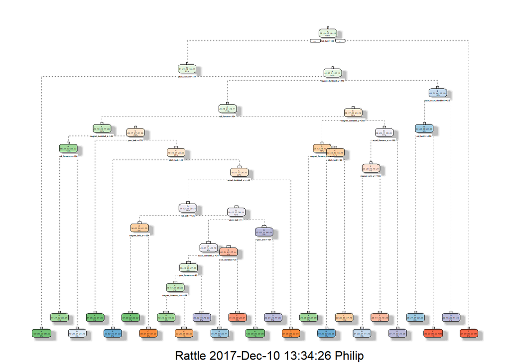